# Customizing fractal trees

```r
library(fractalforest)
```

This vignette presents some features of the `fractalforest` package for customizing fractal trees.

## Install and load developer version of the package

Install developer version.

```r
# install.packages('devtools')
library(devtools)
install_github('sergiocostafh/fractalforest')
```

Load fractalforest package.

```r
library(fractalforest)
```

## Building a simple tree

The fractalforest package uses the Lindenmayer system (L-system) to generate fractal trees. By applying recursive production rules, the package simulates natural branching patterns, allowing for the creation of realistic and customizable tree structures.  
We will start by defining the L-system rules for constructing a simple binary tree, and then we will go into the details.

```r
binary_tree_rules <- data.frame(inp = c("0", "1"),
                         out = c("1[-0]+0", "1"), stringsAsFactors = FALSE)
```

Use the `iterate_lsystem` function to build the string based on the rules (`rules`), the axiom (`init`) and the number of iterations (`n`).

```r
tree_string <- iterate_lsystem(init = "0", rules = binary_tree_rules, n = 5)
tree_string
```

```
#> [1] "1[-1[-1[-1[-1[-0]+0]+1[-0]+0]+1[-1[-0]+0]+1[-0]+0]+1[-1[-1[-0]+0]+1[-0]+0]+1[-1[-0]+0]+1[-0]+0]+1[-1[-1[-1[-0]+0]+1[-0]+0]+1[-1[-0]+0]+1[-0]+0]+1[-1[-1[-0]+0]+1[-0]+0]+1[-1[-0]+0]+1[-0]+0"
```

Build the tree data.frame from the string, and visualize the output.

```r
tree <- build_tree(string = tree_string, angle = 15)
head(tree)
```

```
#> # A tibble: 6 × 5
#>     from_x     to_x from_y  to_y type
#>      <dbl>    <dbl>  <dbl> <dbl> <chr>
#> 1 0        1.04e-17  0     0.170 branch
#> 2 1.04e-17 4.39e- 2  0.170 0.333 branch
#> 3 4.39e- 2 1.29e- 1  0.333 0.480 branch
#> 4 1.29e- 1 2.49e- 1  0.480 0.600 branch
#> 5 2.49e- 1 3.95e- 1  0.600 0.685 branch
#> 6 3.95e- 1 5.59e- 1  0.685 0.729 leaf
```

Visualize the tree.

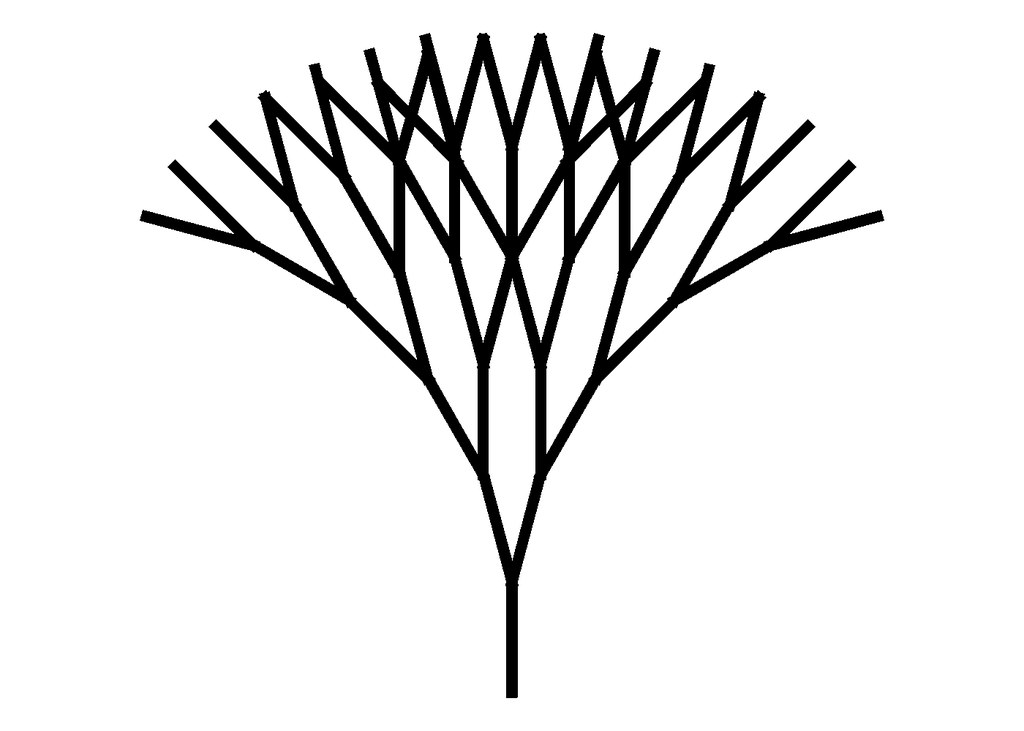

```r
plot_tree(tree)
```

## Exploring rules

To set the rules, the following characters are recognized:

Any other characters in the rule string will be recognized as “a move forward, drawing as you go” instruction. This means that they must be declared in the `inp` column of the rules data frame, and also its corresponding substitution rule (`out` column).

The following example demonstrates the use of parentheses to reduce/increase branch lengths.

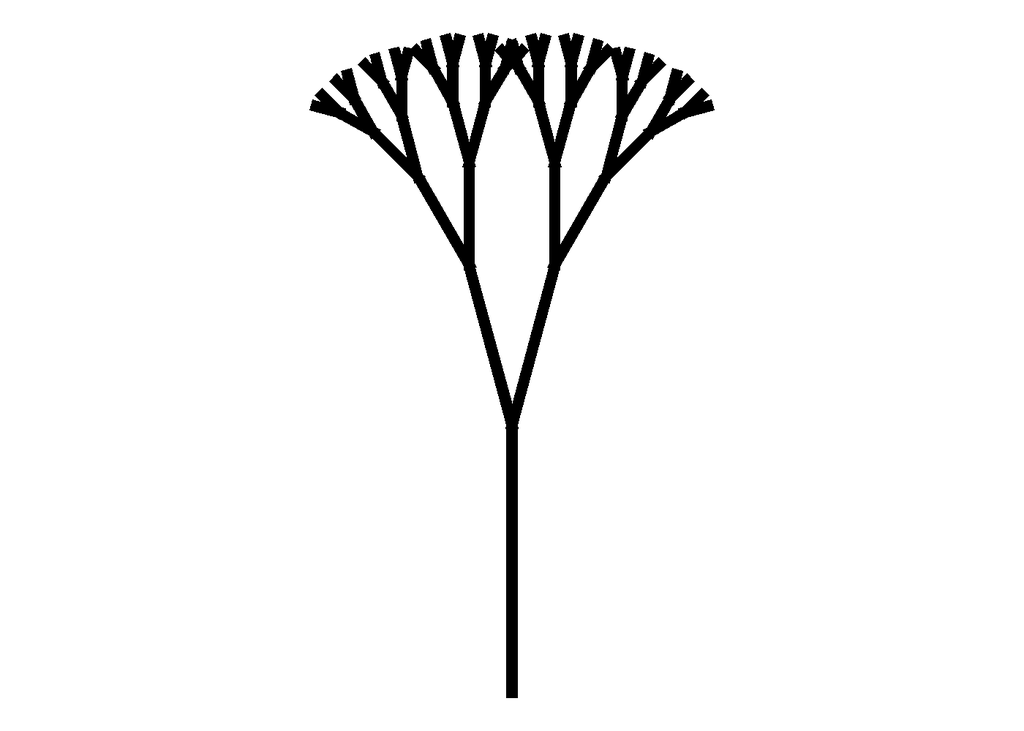

```r
binary_tree_rules <- data.frame(inp = c("0", "1"),
                         out = c("1[-(0)]+(0)", "1"), stringsAsFactors = FALSE)
tree_string <- iterate_lsystem(init = "0", rules = binary_tree_rules, n = 5)
tree <- build_tree(string = tree_string, angle = 15)
plot_tree(tree)
```

## The `iterate_lsystem` function

The `n` argument controls the number of iterations do build the plant. A large `n` value can be time and memory consuming, so be careful.

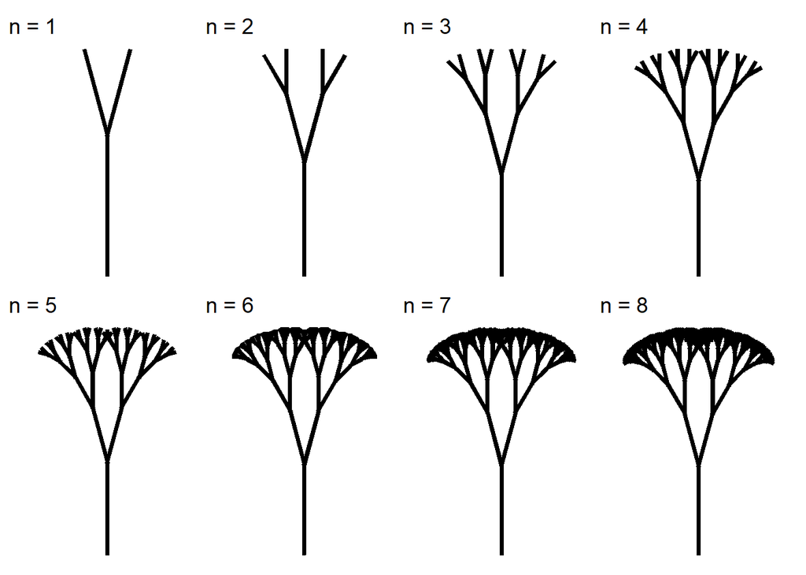

```r
library(ggplot2)
library(patchwork)
library(dplyr)

trees_n <- lapply(1:8,
                  function(x) {
                    iterate_lsystem(init = '0', rules = binary_tree_rules, n = x) %>%
                      build_tree(string = ., angle = 15) %>%
                      plot_tree()+
                      labs(title = paste0('n = ', x))
  })

wrap_plots(trees_n, nrow = 2, heights = c(1,1))
```

Below are some other rules for simulating plants with different morphologies.

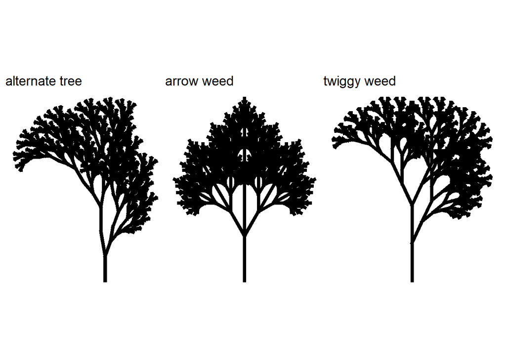

```r
alternate_bush_rules <- data.frame(inp = c("0", "1"),
                          out = c("1[+1][--(0)]+1-1[+++(0)]-(0)", "1"), stringsAsFactors = FALSE)
tree_string <- iterate_lsystem(init = "0", rules = alternate_bush_rules, n = 6)
tree1 <- build_tree(string = tree_string, angle = 10) %>%
  plot_tree()+
  labs(title = 'alternate tree')

arrow_weed_rules <- data.frame(inp = c("0", "1"),
                          out = c("1[+(0)][-(0)](10)", "1"), stringsAsFactors = FALSE)
tree_string <- iterate_lsystem(init = "0", rules = arrow_weed_rules, n = 6)
tree2 <- build_tree(string = tree_string, angle = 30) %>%
  plot_tree()+
  labs(title = 'arrow weed')

twiggy_weed_rules <- data.frame(inp = c("0", "1"),
                          out = c("1[-(0)]1[-(0)]+(0)", "1"), stringsAsFactors = FALSE)
tree_string <- iterate_lsystem(init = "0", rules = twiggy_weed_rules, n = 6)
tree3 <- build_tree(string = tree_string, angle = 25) %>%
  plot_tree()+
  labs(title = 'twiggy weed')

tree1 + tree2 + tree3
```

## Predefined models

The fractalforest package has some predefined models for constructing fractal trees from L-system rules. These models can be accessed from the `fractal_tree_model` function. The function takes a mandatory argument (`tree_model`) and an optional one (`n_iter`) that controls the number of iterations for string construction.  
There are 10 pre-implemented tree templates, as follows (default `n_iter` between parentheses):  
-1 or “binary_tree” (6);  
-2 or “alternate_tree” (5);  
-3 or “arrow_weed” (5);  
-4 or “twiggy_weed” (5);  
-5 or “stochastic_fuzzy_weed” (4);  
-6 or “crooked_binary_tree” (6);  
-7 or “crooked_alternate_tree” (5);  
-8 or “crooked_arrow_weed” (5);  
-9 or “crooked_twiggy_weed” (5);  
-10 or “crooked_stochastic_fuzzy_weed” (4).

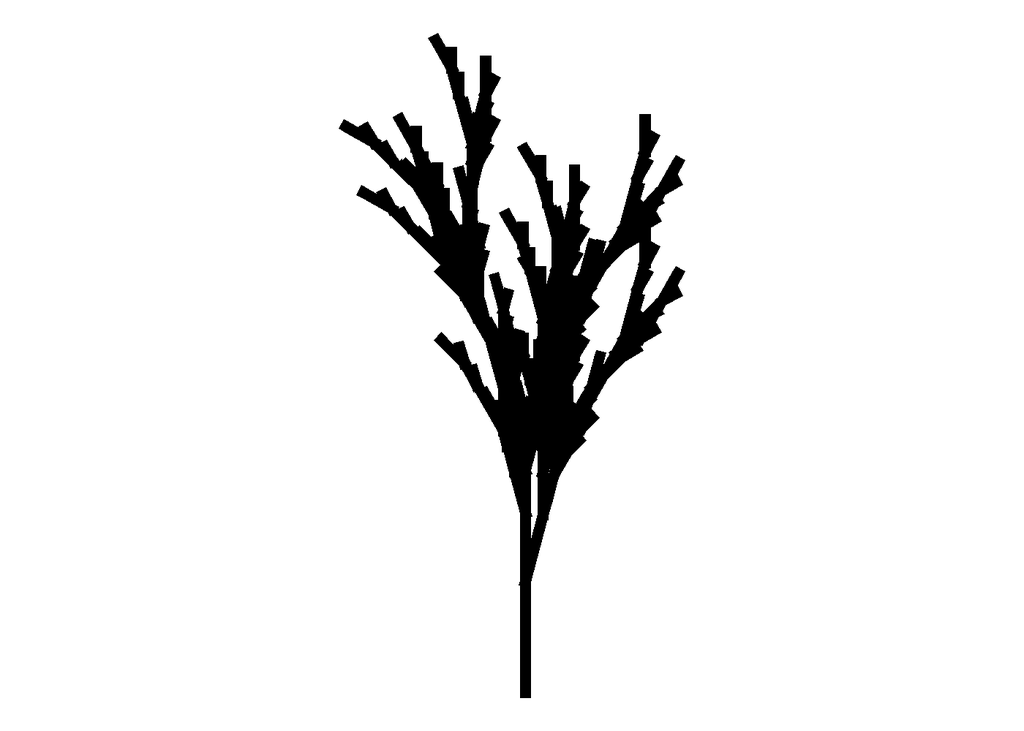

```r
fractal_tree_model(5) %>%
  build_tree() %>%
  plot_tree()
```

## The `build_tree` function

The purpose of this function is to build a data frame that contains the coordinate matrix and some other information about the plant, such as the differentiation between branches and leaves and the diameters along the branches.  
The `h_reduction` parameter in the `build_tree` function, controls the reduction factor of the length.

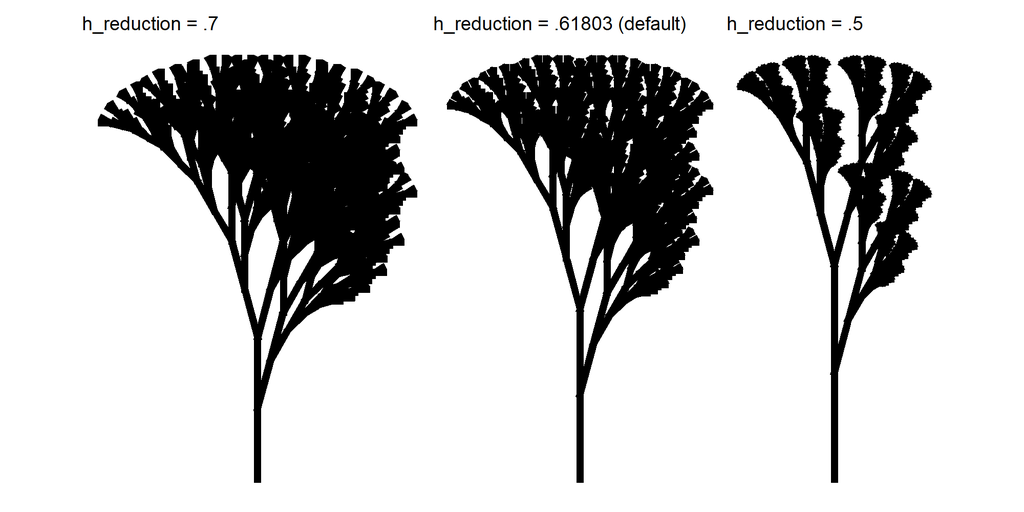

```r
tree1 <- build_tree(string = tree_string, angle = 15, h_reduction = .7) %>%
  plot_tree()+
  labs(title = 'h_reduction = .7')

tree2 <- build_tree(string = tree_string, angle = 15) %>%
    plot_tree()+
  labs(title = 'h_reduction = .61803 (default)')

tree3 <- build_tree(string = tree_string, angle = 15, h_reduction = .5) %>%
    plot_tree()+
  labs(title = 'h_reduction = .5')

tree1 + tree2 + tree3
```

The `randomness` argument, as the name suggests, allows one to apply randomness to the angles and lengths of the plant. It must be set to `TRUE` if its effects are desired The amount of randomness can be controlled by the `angle_cv` and `length_cv` arguments, which define the angle and length variation coefficients, respectively. By default, these two arguments are set to 0.1,

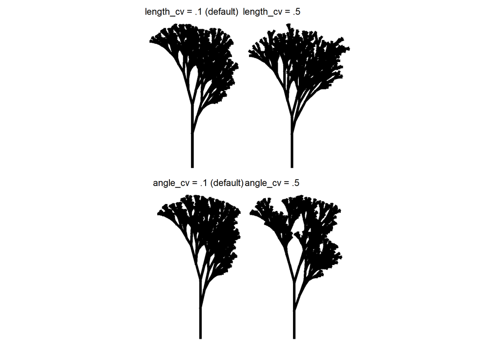

```r
tree1 <- build_tree(string = tree_string, angle = 15, randomness = TRUE) %>%
  plot_tree()+
  labs(title = 'length_cv = .1 (default)')

tree2 <- build_tree(string = tree_string, angle = 15, randomness = TRUE, length_cv = .5) %>%
  plot_tree()+
  labs(title = 'length_cv = .5')

tree3 <- build_tree(string = tree_string, angle = 15, randomness = TRUE) %>%
  plot_tree()+
  labs(title = 'angle_cv = .1 (default)')

tree4 <- build_tree(string = tree_string, angle = 15, randomness = TRUE, angle_cv = .5) %>%
  plot_tree()+
  labs(title = 'angle_cv = .5')

(tree1 + tree2) / (tree3 + tree4)
```

It’s possible to set the plant height setting the `height` parameter in the `build_tree` function. It will affect the resulting coordinates in the output.  
To visualize the y axis with the height measure, `ggplot2` functions can be used together with `plot_tree` function.

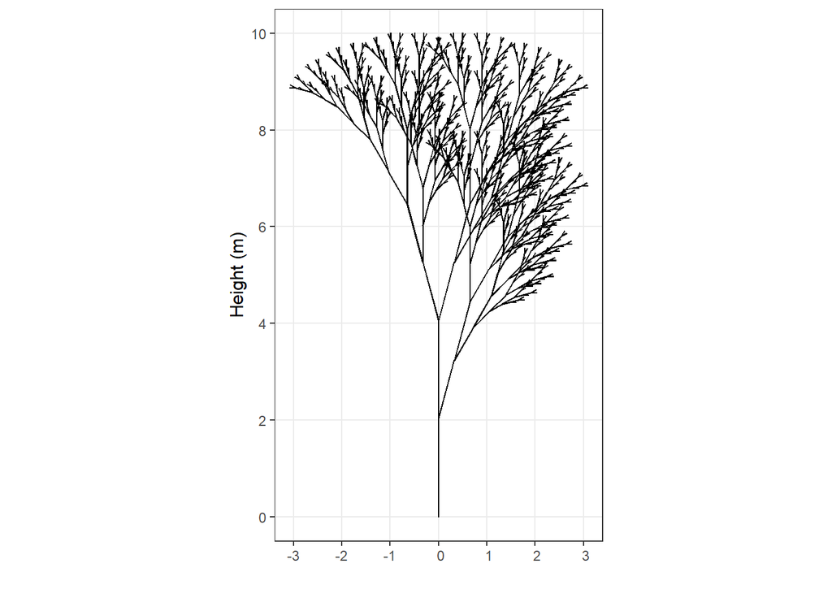

```r
tree <- build_tree(string = tree_string, angle = 15, height = 10)
plot_tree(tree)+
  labs(x = '', y = 'Height (m)')+
  theme_bw()
```

As well as the `height`, in the `build_tree` function it is possible to define the `diameter` of branches, whose reduction is defined by the parentheses in the rules declared in the `iterate_lsystem` function, in the same way as lengths. The argument `d_reduction` controls the reduction factor for the diameters.

The density of leaves in the tree crown can be customized by the `leaf_size` argument.

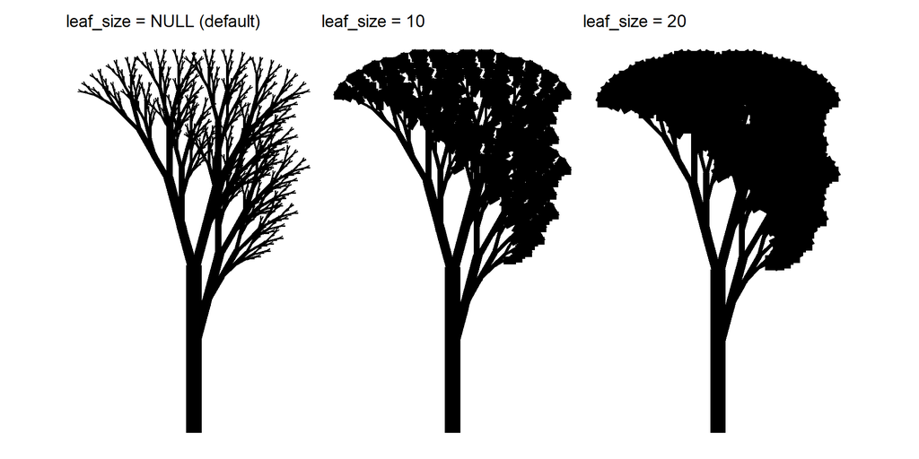

```r
p1 <- build_tree(string = tree_string, angle = 15, height = 10, diameter = 20) %>%
  plot_tree(d_col = diameter)+
  labs(title = 'leaf_size = NULL (default)')

p2 <- build_tree(string = tree_string, angle = 15, height = 10, diameter = 20, leaf_size = 10) %>%
  plot_tree(d_col = diameter,)+
  labs(title = 'leaf_size = 10')

p3 <- build_tree(string = tree_string, angle = 15, height = 10, diameter = 20, leaf_size = 20) %>%
  plot_tree(d_col = diameter)+
  labs(title = 'leaf_size = 20')

p1 + p2 + p3
```

## Visualizing the plant and the `plot_tree` function

This function was implemented on top of `ggplot2` and for this reason it can be used together with several functions of the package.  
To visualize the diameters along the plant, the diameter column must be declared in the `d_col` argument.

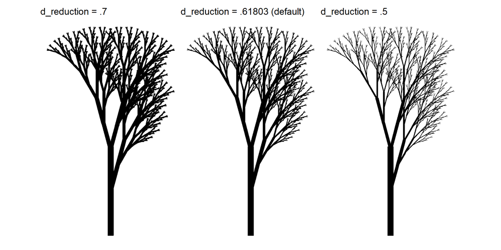

```r
tree1 <- build_tree(string = tree_string, angle = 15, height = 5, diameter = 7, d_reduction = .7) %>%
  plot_tree(d_col = diameter)+
  labs(title = 'd_reduction = .7')

tree2 <- build_tree(string = tree_string, angle = 15, height = 5, diameter = 7) %>%
  plot_tree(d_col = diameter)+
  labs(title = 'd_reduction = .61803 (default)')

tree3 <- build_tree(string = tree_string, angle = 15, height = 5, diameter = 7, d_reduction = .5) %>%
  plot_tree(d_col = diameter)+
  labs(title = 'd_reduction = .5')

tree1 + tree2 + tree3
```

Colors can be used to differentiate leaves and branches, by declaring the `leaf_color` and `branch_color` arguments. The `build_tree` function identifies as leaves all the branches positioned at the ends of the plant. This information is stored in the “type” column, which can be used to assign colors.

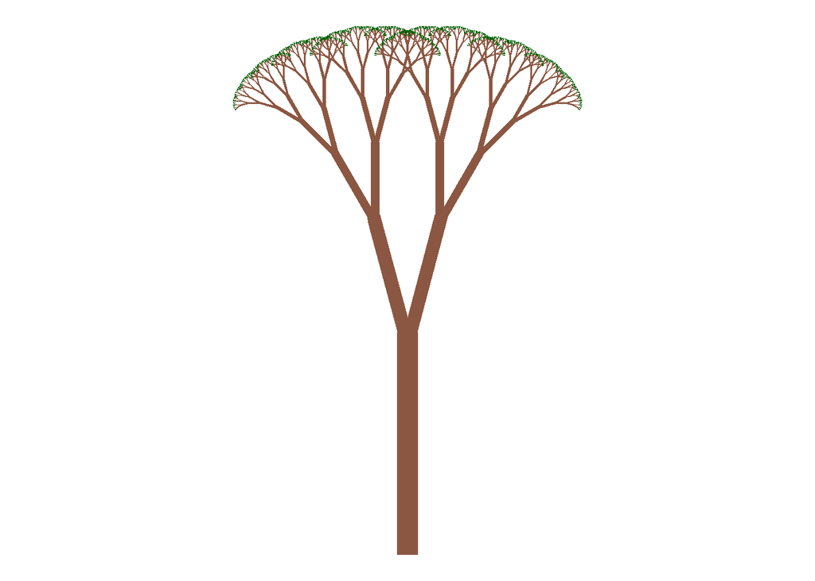

```r
library(patchwork)
tree_string <- iterate_lsystem(init = "0", rules = binary_tree_rules, n = 10)
tree <- build_tree(string = tree_string, angle = 15, height = 10, diameter = 20)

plot_tree(tree, d_col = diameter, branch_color = 'lightsalmon4', leaf_color = 'darkgreen')
```